*Created by Petteri Nevavuori <petteri.nevavuori@gmail.com>*

**CHIO & FREEMAN: MACHINE LEARNING & SECURITY (2018)**  
*Otsikot kirjan mukaan, muutoin suomeksi.*

# Sisällysluettelo

## Anomaly Detection

Poikkeamien (*anomaly, outlier*) havainnoinnilla tarkoitetaan kyberturvallisuudessa odottamattomien murtojen ja tunkeutumisten havaitsemista IT-järjestelmissä. Tavallista on, että murron havaitsemisen hetkellä vahinko on tapahtunut jo päiviä aiemmin. Poikkeamien havainnointi ei rajoitu vain kyberturvaan, vaan sitä käytetään mm. teollisuudessa järjestelmä- tai laiterikkojen ja pankkisektorilla luottopetosten havaitsemiseen. Poikkeamat voidaan oppia havaitsemaan joko luokitellusti eli ohjatusti tai oppimimalla vain tavanomaisen datan piirteet ja merkitsemällä siitä poikkeavat havainnot poikkeamiksi (*novelty detection*).

Poikkeamien havainnointi linkittyy vahvasti aikasarjojen (*time series*) mallinnukseen. Osakekurssidatan tavoin myös esimerkiksi Bash-komentotulkin komentoja voidaan käsitellä aikasarjamaisena (*time series*) datana, joskin ajallisen jakauman sijasta ollaan ennemmin tapahtumakeskeisen (*event-driven*) aikasarjadatan kanssa. Poikkeamalla tarkoitetaan tässä tapauksessa havaintoa, joka eroaa merkittävästi aiemmista tavanomaisista havainnoista (komennot ja komentojen sarjat).

### When to Use Anomaly Detection Versus Supervised Learning

Kuten ensimmäisessä kappaleessakin jo todettiin, valinta poikkeamien havainnointimenetelmän ja suoran ohjatun oppimisen keinoin koulutetun mallin välillä on tapauskohtaista. Merkittävimmässä roolissa on data, sillä ohjattu oppiminen vaatii riittävän määrän oikein luokiteltuja historiallisia havaintoja kouluttuakseen. Mikäli tällaista dataa ei ole saatavilla, on ryhmittelymenetelmien käyttö perusteltua, joskin niitä rajoittavat edellisen kappaleen esitellyt huomiot. Ylipäätään poikkeamien kanssa työskennellessä poikkeamien havainnointiin keskittyvät menetelmät toimivat silti hyvin, sillä poikkeamaksi luokiteltavat havainnot ovat juuri niitä - harvinaisia.

### Intrusion Detection with Heuristics

Vielä nykypäivänäkin luotetaan manuaalisesti määritettyihin rajoihin, heuristiikkoihin ja tilastollisiin profiileihin poikkeavan käyttäytymisen havaitsemisessa. Esimerkki tästä on tietokantakyselyiden käyttäjäkohtainen määräraja-arvo, minkä ylittyessä käyttäjä merkitään poikkeamaksi. Tämänkaltaisten rajojen asettaminen vaatii kuitenkin usein tietoa jopa asioista, jota ei välttämättä ole saatavilla tai ihmisen saavutettavissa. Yksinkertainen raja-arvo on mahdollista korvata esimerkiksi liukuvan ikkunan keskiarvoon suhteutetulla raja-arvolla, mutta tässäkin tapauksessa kyse on yhteen piirteeseen sidotusta raja-arvosta. Tavallisempaa on, että poikkeama on tunnistettavissa monen piirteen yhteisvaikutuksesta. Tässä koneoppimismenetelmät tarjoavat soveliaan aputyökalun.

### Data-Driven Methods

Optimaalisesti toimivalle poikkeamien havaintomenetelmälle voidaan asettaa joitain ehtoja.

Ensimmäinen näistä on riittävän hyvä tarkkuus, jossa on mahdollisimman vähän väärin luokiteltuja havaintoja (*low false positives and negatives*). Vaikka ensiajattelemalta mielummin agressiivisesti uhiksi luokitteleva (*high false positives*) tuntuu varman päälle pelaamiselta, on jokaisella uhaksi luokitellulle havainnolle laskettava myös selvitystyön kautta muodostuva kustannus. Samoin jatkuva susivaaran huutaminen johtaa siihen, että toden tullen asioiden selvittämisestä vastaavien henkilöstön jäsentene kynnys tarttua toimeen kasvaa aivan turhaan.

Toinen ehdoista on asetusten säätämisen, virittämisen ja ylläpidon helppous. Mikäli kyseessä on esimerkiksi raja-arvoilla toimiva havaintomenetelmä, on raja-arvoja päästävä säätämään riittävän helposti. Ylipätään menetelmän aloituskonfiguroinnin helppous ja ylläpidettävyys määrittävät havaintojärjestelmän käytettävyyttä vahvasti. Tämä on erityisen tärkeää esimerkiksi mallin alkaessa tuottaa odottamattomia tuloksia.

Kolmas on mukautumiskyky (*adaptation*) ajan myötä muuttuviin datan trendeihin, joista kausivaihtelut (*seasonalities*) ovat yksi esimerkki. Tämä erityisen tärkeää menetelmille, jotka toimivat aikasarjadatan kanssa. IT-järjestelmien kohdalla vaikkapa käyttäjämäärät ovat hyvin erilaisia arkena ja viikonloppuina. Samoin tietyltä maantieteelliseltä alueelta tulevat verkkopyynnöt lisääntyvät ja pienentyvät aaltomaisesti päivän ja yön välillä. Kausivaihteluun mukautumattomuus johtaa helposti vääriin luokittelutuloksiin.

Neljäs ehto on toimintakyvyn säilyminen eriluontoisten datasettien kanssa. Tällä tarkoitetaan erityisesti sitä, ettei malli toimi vain tiettyyn jakaumaan (esim. normaalijakauma) sovittuvan datan kanssa, vaan se kykenee tuottamaan luotettavia tuloksia myös muilla tavoin jakautuneiden datojen kanssa.

Toiseksi viimeisenä eli viidentenä ehtona esitetään menetelmän laskennallinen tehokkuus, sillä uhkien tunnistaminen vaatii joissain tapauksissa jopa reaaliaikaista toimintaa. Tällöin koulutetun mallin on kyettävä ottamaan data vastaan ja tuotettava luokittelutulos nopeasti, jolloin laskennallisesti liian raskaat menetelmät jäävät näissä tilanteissa käyttökelvottomiksi.

Viimeseksi ehdoksi asetetaan kyky päästä käsiksi luokittelutulosten perusteisiin. Raja-arvonmenetelmillä tämä ei ole ongelma, mutta vähänkään monimutkaisempien koneoppimismenetelmien kanssa yksiselitteisten perustelujen noutaminen kullekin luokittelutulokselle on jopa oma tutkimuksen kenttänsä. Rajoitetun tutkinta-ajan puitteissa menetelmän tarjoama selityskyky on arvokas tuki luokittelujen tarkastukseen.

### Feature Engineering for Anomaly Detection

Koneoppimisessa datalla ja sen piirteillä on äärimmäisen suuri merkitys menetelmien suorituskyvyn kannalta. Joissain tapauksissa luokitteluun tarvittavat piirteet ovat sellaisinaan helposti saatavilla, kuten prosessorin kuormitus. Usein on kuitenkin niin, että piirteet on yhdisteltävä monista yksittäisistä piirteistä eri tavoin. Tätä kutsutaan piirteiden rakentamiseksi (*feature engineering*). Tässä aliluvussa keskitytään piirteiden rakentamiseen isäntäjärjestelmään murtautumisen (*host intrusion*), verkkomurtautumisen (*network intrusion*) ja web-sovellusten murtautumisen (*we application intrusion*) havaitsemisen näkökulmasta. Jokaisella näistä osa-alueista on omat erityishuomionsa, mutta piirteiden rakentaminen poikkeamien havaitsemiseksi ei missään tapauksessa rajoitu näihin kolmeen osa-alueeseen.

#### Host Intrusion Detection

Isäntäjärjestelmällä tarkoitetaan vaikkapa palvelinta, kannettavaa tietokonetta tai sulautettua järjestelmää (*embedded system*). Isäntäjärjestelmän murtautumisen havaitsemista varten on tarpeen kehittää omat tapauskohtaiset mittarinsa ja määrittää kerättävät signaalit. Järjestelmä- ja verkkotaso on hyvä signaalien keruun lähtökohta ja keruuseen löytyy monia aputyökaluja. Tällöin keruun kohteena ovat järjestelmän tarjoamat signaalit ja tunnistamisen kohteena taas murron ilmaisimet (*indicators of compromise*). Kerättäviä signaaleja ovat esimerkiksi

- käynnissä olevat prosessit,
- käyttäjätilit,
- järjestelmän ytimen ladatut moduulit (*kernel modules*),
- DNS-haut,
- avatut verkkoyhteydet,
- järjestelmän ajastettujen toimintojen muutokset,
- taustaprosessit,
- käynnistyksen aikaiset käynnistetyt operaatiot,
- käyttöjärjestelmän rekisteritietokantatiedot (.plist-tiedostot),
- väliaikaistiedostot ja
- selainlaajennokset.

Eräs tällainen työkalu on SQL-syntaksilla käytettävä [osquery](https://osquery.io). Se tarjoaa mahdollisuuden muodostaa ajastettuja kyselyjä järjestelmän eri osista tulevan tiedon keräämiseksi. Seuraavassa esimerkissä lähdetään siitä oletuksesta, että järjestelmässä piilevä haittaohjelma vaikuttaa ja on täten havaittavissa järjestelmätason tapahtumissa. Työkalun asentamisen jälkeen sen käyttö tapahtuu komentoriviltä käynnistyskomennolla `osqueryi`.

Esimerkiksi järjestelmän kymmenen käyttäjätilin nimien nouto tapahtuu seuraavalla komennolla.

```python
% % bash
osqueryi
SELECT username FROM users ORDER BY username ASC LIMIT 10
```

```
+----------------+
| username       |
+----------------+
| _apt           |
| avahi          |
| avahi-autoipd  |
| backup         |
| bin            |
| colord         |
| cups-pk-helper |
| daemon         |
| dnsmasq        |
| games          |
+----------------+
```

Kolmen eniten muistia vievän prosessin kutsu tapahtuu seuraavasti.

```python
% % bash
osqueryi
SELECT pid, name, resident_size FROM processes ORDER BY resident_size DESC LIMIT 3
```

```
+------+-------------+---------------+
| pid  | name        | resident_size |
+------+-------------+---------------+
| 3928 | Web Content | 453764000     |
| 9353 | slack       | 436136000     |
| 3868 | firefox     | 393992000     |
+------+-------------+---------------+
```

Tämä työkalu tarjoaa ennenkaikkea kyvyn tehdä kyselyjä ajallisesti relevanttien muutosten havaitsemiseen. Kuten `osquery`n etusivullakin kerrotaan, yleinen haittaohjelmien toimintatapa on poistaa itsensä tiedostojärjestelmästä käynnistämisen jälkeen. Tällaisten prosessien haku onnistuu seuraavalla komennolla. Tämän notebookin kirjoitushetkellä tällaisia prosesseja ei löytynyt.

```python
% % bash
osqueryi
SELECT * FROM processes WHERE on_disk = 0
```

Työkalu on myös skriptattavissa siten, että kyselyjä voidaan automatisoida ja kyselyjen tulokset tallettaa tiedostoon. Samoin työkalu tarjoaa valmiita ominaisuuksia monien järjestelmätason tapahtumien automaattiseen seurantaan. Tärkeää on kuitenkin ymmärtää tämänkin työkalun rajoitukset. Se on suunniteltu toimimaan vain ja ainoastaan valvotussa ja luotetussa järjestelmässä. Siksi asiantunteva haitallinen toimija voi pyrkiä vaikuttamaan työkalun palauttamiin tietoihin ja näin tehdä jäljistään entistä vaikeammin havaittavia. Muitakin työkaluvaihtoehtoja löytyy.

#### Network Intrusion Detection

IT-järjestelmissä ulkoinen vaikuttaminen tapahtuu lähes yksinomaan verkon ylitse. Muun muassa bottiverkkojen ja kehittyneempien pysyväisuhkien tapauksissa haitallisella toimijalla on pääsy kohdejärjestelmiin verkon yli siten, että kohdejärjestelmät saadaan toimimaan vaikuttajan tahdon mukaisesti. Tämän vuoksi verkon yli tapahtuvien murtojen havainnoinnilla on suuri ennaltaehkäisevä tai informoiva merkitys.

Työkalujen kirjo tähän on laaja ja kehittynyt. Työkaluja löytyy aina yksinkertaisemmista [protokollatason](http://www.tcpdump.org) työkaluista aina [kehittyneempiin](https://www.bro.org) työkaluihin. Työkalujen perustana on isäntäjärjestelmän ja ulkomaailman välise verkkoliikenteen tarkkailu. Vihamielinen verkkoliikenne tavataan tunnistaa esimerkiksi tunnetun verkkoliikennejäljen (*signature*) tai poikkeamien havainnoinnin avulla, joista jälkimmäinen on tässä osiossa huomion keskipisteenä. [Snort](https://www.snort.org), esimerkiksi, on tunnettu avoimen lähdekoodin [tunkeilijan havaintojärjestelmä](https://fi.wikipedia.org/wiki/Tunkeilijan_havaitsemisj%C3%A4rjestelm%C3%A4) (*intrusion detection system, IDS*), joka tutkii verkkoliikennettä ja paketteja reaaliaikaisesti poikkeamien havaitsemiseksi.

Verkkoliikenteen poikkeamien havainnoinnissa verkkoliikenteestä tavataan erotella sen metadata ja sisältö. Metadataan keskittyvässä tunnistamisessa tarkastellaan verkkoliikenteen pakettien tilatietoja (*stateful packet inspection, SPI*) koskematta itse sisältöön. Näin paketteja voidaan yhdistää toisiin, jo havaittuihin paketteihin. Tällöin tavanomaisista ja ennustettavista paketetista eroavat paketit on mahdollista tunnistaa ja luokitella poikkeamiksi. Näin voidaan havaita mm. palvelunestohyökkäykset (*denial of service, DoS*) IP- ja porttitason laajan tilannekuvan vuoksi. Sovellustasolle asti ei näillä keinoin kuitenkaan ylletä.

Pakettien syvätarkkailu (*deep packet inspection, DPI*) ottaa pakettien ylä- ja alatunnisteiden lisäksi huomioon myös pakettien sisällön. Sisältötietoa analysoimalla on mahdollista päästä käsiksi niihin signaaleihin, joiden avulla voidaan tunnistaa mm. roskaposti, haittaohjelmat tai hienovaraisetkin poikkeamat. Pakettien syvätarkkailu on kuitenkin laskennallisesti raskaampaa sisällön salausten purkamisen vuoksi, minkä takia sitä ei voida kovin helposti soveltaa reaaliaikaiseen tarkkailuun. Syvätarkkailusovellukset ([Bro](https://www.bro.org)) tarkkailevat verkkoliikenteen tapahtumia eli paketteja ja toimivat niille asetettujen ohjeiden (*policy*) mukaisesti. Näin mahdollista esimerkiksi tunnistaa SQL-injektiohyökkäykset, jossa tietokantakyselyyn pyritään syöttämään haitallisia merkkejä tai vaikkapa [*cross-site scripting*](https://fi.wikipedia.org/wiki/Cross_site_scripting) hyökkäykset. Ohjeet ovat kuitenkin melko vahvasti käyttökohderiippuvaisia. Koska pakettien syvätarkkailu vaatii kyvyn lukea pakettien sisältöä, on sitä käytettäessä myös salaukset ainakin hetkellisesti purettava - tämä muodostaa oman riskinsä menetelmän käytölle.

Verkkomurtojen mallintamisen piirteisiin (*features*) löytyy kilpailuista koostettua tietoa jo viime vuosituhannelta ([KDD Cup 1999](http://www.kdd.org/kdd-cup/view/kdd-cup-1999/Data)). Vaikka datasetit ovat vanhoja ja vaillinaisia, ovat niissä käytetyt piirteet edelleen hyvä lähtökohta mallintamiseen tähtäävän datan keruulle. Datasetin [piirteistä](http://www.kdd.org/cupfiles/KDDCupData/1999/kddcup.names) löytyvät seuraavat muuttujat:

```
back,buffer_overflow,ftp_write,guess_passwd,imap,ipsweep,land,loadmodule,
multihop,neptune,nmap,normal,perl,phf,pod,portsweep,rootkit,satan,smurf,
spy,teardrop,warezclient,warezmaster,duration,protocol_type,service,flag,
src_bytes,dst_bytes,land,wrong_fragment,urgent,hot,num_failed_logins,
logged_in,num_compromised,root_shell,su_attempted,num_root,num_file_creations,
num_shells,num_access_files,num_outbound_cmds,is_host_login,is_guest_login,
count,srv_count,serror_rate,srv_serror_rate,rerror_rate,srv_rerror_rate,
same_srv_rate,diff_srv_rate,srv_diff_host_rate,dst_host_count,dst_host_srv_count,
dst_host_same_srv_rate,dst_host_diff_srv_rate,dst_host_same_src_port_rate,
dst_host_srv_diff_host_rate,dst_host_serror_rate,dst_host_srv_serror_rate,
dst_host_rerror_rate,dst_host_srv_rerror_rate
```

#### Web Application Intrusion Detection

Pakettien syvätarkkailun ohella myös palvelimien lokitiedostojen tarkkailulla voidaan saavuttaa astetta syvempi ymmärrys mahdollisista uhista. Lokitapahtumat ilmentävät ennenkaikkea käyttäjien toimintaa. Yksittäinen lokirivi sisältää tavallisesti tietoa käyttäjän IP-osoitteesta, tapahtuma-ajasta, pyynnöstä ja käyttäjän järjestelmästä. Usein POST-kutsujen runko (*body*) jää lokitiedoista oletusarvoisesti pois, joskin tämä on kierrettävissä palvelinkohtaisilla säädöillä.

Lokitapahtumista voidaan eristää ainakin seuraavat piirteet:

- Käyttötilastot IP-osoitetasolla
- URL-polkujen poikkeavuudet
- Erikoismerkkien käytöt ja dekoodaukset toiminnan piilottamiseksi
- Epätavalliset sivuston käyttöpolut (*sequence of access*)
- Käyttäjäpoikkeamat käyttäjien järjestelmätasolla

### Anomaly Detection with Data and Algorithms

Piirteiden jalostamisen jälkeen edetään kohti mallinnusta. Poikkeamien havaitsemisessa on olennaista, ettei yhtä kaiken kattavaa ratkaisua ole olemassa. Siksi parhaiten soveltuvan mallinnusmenetelmän eli algoritmin löytäminen on tutkimuksen ja kokeilun tulosta. Datan ominaisuuksilla on merkittävä rooli algoritmin valinnassa, etenkin tavanomaisesta poikkeavan havaitsemisessa (*novelty detection*) verrattuna poikkeamien luokittelun oppimisessa (*outlier detection*).

Tässä osiossa pyritään käymään läpi laaja kirjo poikkeamien havaitsemiseen soveltuvia menetelmiä. Menetelmät luokitellaan osion alaotsikoiden mukaisesti viiteen ryhmään:

- Ennustaminen ohjatulla oppimisella
- Tilastolliset tunnusluvut
- Ohjaamaton oppiminen
- Yhteensopivuuden astetestit (*goodness of fit*)
- Tiheyteen perustuvat menetelmät

#### Forecasting (Supervised Machine Learning)

Ennustaminen on poikkeamien havaitsemisen osalta suoraviivaista menneen oppimista tulevaisuuden ennustamiseksi. Mikäli havainto poikkeaa ennustemallin tuottamasta tavanomaista vastaavasta, luokitellaan havainto poikkeamaksi. Kyseessä on tällöin nykyisten arvojen ennustaminen menneisyyttä hyödyntäen, toisin sanoen aikasarjaregressio. Ihmisille helppo ajallisten piirteiden havainnointi on koneille astetta haasteellisempaa, mihin datajoukon kohinalla on suuri vaikutus. Kohinan ja aikasarjojen ominaispiirteiden vuoksi yksinkertaiset lineaarimallit eivät sovellu tähän tehtävään hyvin.

Aikasarjasta eritellään seuraavat kuvaavat piirteet:

- **Trendit**: Pitkän aikavälin huomattavat muutokset, joiden puitteissa paikalliset vaihtelut tapahtuvat.
- **Kaudet** (*seasons*): Ajallisesti toistuvat piirteet, kuten vuorokausirytmin tai vuoden ajan mukaan havaittavat vaihtelut.
- **Kierrot** (*cycles*): Kuten kaudet, mutta vähemmän selvällä tai kiinteällä ajallisella erolla.

Ennustaminen on intuitiivinen poikkeamien havaitsemisen menetelmä. Tavoite- eli häiriötöntä tilaa hyvin mallintamalla kyetään uusia tapahtumia peilaamaan mallin avulla ja näin eristämään mallinnetusta tilasta selkeästi poikkeavat havainnot. Datasta riippuen joko yksinkertaisempi ARIMA-malli tai kompleksimman datan kanssa toimiva LSTM-malli tuottavat hyviä tuloksia. Tarvittaessa dataa voidaan myös tuottaa keinotekoisesti, joskaan kiistatonta se ei ole.

Mikäli ennustemallin koulutukseen käytettävässä datassa on itsessään poikkeamia, ei menetelmien käyttö ole suotavaa - tällöin malli oppii mallintamaan myös niitä, eikä malli ilmaise poikkeamia toivotulla tavalla. Vaikkakin kirjassa sanotaan, että parhaiten aikasarjaennustaminen toimii yksipiirteisellä numerodatalla, on neuroverkkojen käytöllä mahdollista saavuttaa toimivia malleja myös epälineaarisesti riippuvien monimuuttujaisten datajoukkojen kanssa.

##### ARIMA

Autoregressiivinen integroidun liukuvan keskiarvon (*autoregressive integrated moving average, ARIMA*) menetelmät ovat aikasarjojen mallinnukseen kehitetty funktioiden perhe. Kyseessä ovat ennenkaikkea tilastolliset mallit, jotka mallintavat lineaarisia riippuvuussuhteita piirteiden edeltäviin arvoihin nähden. Tätä kutsutaan autokorrelaatioksi, eli korrelointia itsensä kanssa menneeseen ajanhetkeen nähden. Keskiarvoistusta säätämällä saadaan joko pehmeämpiä tai karkeampia ennustekäyriä ja menetelmään voidaan lisätä myös kausittaisuutta mallintava komponentti (*seasonal ARIMA, SARIMA*).

Oikean mallinnusfunktion valinta edellyttää aina datan visualisointia ja tarkastelua, sillä esimerkiksi kausittaisuus ja kierrot määrittävät jokseenkin käytettävää mallia. Hyväksi malliksi ymmärretäänkin sellainen, joka saavuttaa korkean korrelaation menneiden pisteiden kanssa. Mallin sovittuvuutta säädetään sekä liukuvan keskiarvon ikkunan koolla ja tietyillä kertoimilla, jotta aikasarja saadaan tilastollisesti pysyvä keskiarvon ja hajonnan osalta.

ARIMA-mallin toimintaa esitellään prosessorin laskentatehon muutoksia näyttävällä datasetillä. Datasetti on esitelty alla. Datasetti sisältää kaksi muuttujaa, ajan ja käyttöasteen. Useamman muuttujan kanssa on jo jouduttava tekemään ARIMA-ensemble, sillä mallilla voidaan ennustaa vain yhtä arvoa kerrallaan.

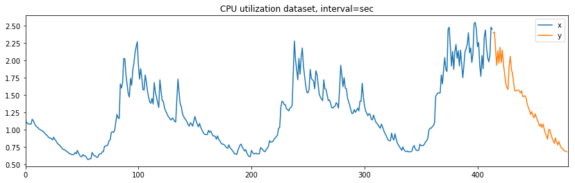

```python
import os
import pandas as pd
import matplotlib.pyplot as plt
%matplotlib inline
plt.rcParams['figure.figsize'] = (14, 4)
dataset = pd.read_csv(os.path.join(os.getcwd(), 'datasets', 'cpu-a.csv'))
x, y = dataset.iloc[:-66], dataset.iloc[-66:]
fig, ax = plt.subplots()
x.plot(ax=ax), y.plot(ax=ax)
ax.legend(['x', 'y'])
plt.title("CPU utilization dataset, interval=sec")
plt.xlim(0, len(dataset))
plt.show()
```

Kirjan käyttämän paketin sijasta tässä mallintamiseen käytetään `statsmodels.api.tsa`-paketista löytyvää `ARIMA`-mallin implementaatiota. Mallin alustukseen on differointiarvoksi määritetty 0, jolloin tavoitteena on tuottaa aikaan nähden tilastollisesti muuttumaton eli stationäärinen aikasarja. Muut luvut on etsitty manuaalisesti kokeilemalla.

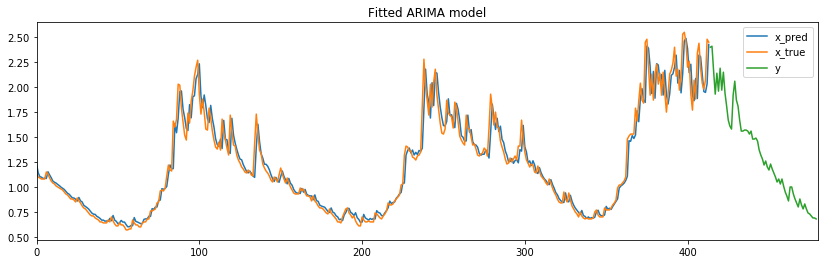

```python
import statsmodels.api as sm_api
model = sm_api.tsa.ARIMA(endog=x.cpu, order=(8, 0, 1)).fit(disp=False)
fig, ax = plt.subplots()
model.plot_predict(ax=ax)
y.plot(ax=ax)
ax.legend(['x_pred', 'x_true', 'y'])
plt.title('Fitted ARIMA model')
plt.xlim(0, len(dataset))
plt.show()
```

Malli sovittuu dataan hyvin. Seuraavaksi testataan sen kykyä ennustaa tulevaa, eli tehdään ennuste datasetin `y`-osajoukkoa vastaan.

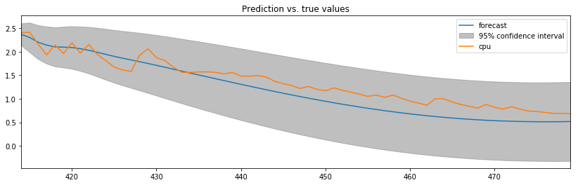

```python
fig, ax = plt.subplots()
model.plot_predict(start=len(x), end=len(x)+len(y),
                   plot_insample=False, dynamic=True, ax=ax)
y.plot(ax=ax)
plt.title('Prediction vs. true values')
plt.xlim(y.index[0], y.index[-1])
plt.show()
```

Ennuste noudattaa arvojen trendiä.

##### Artificial Neural Networks

Vain yhtä muuttujaa kerrallaan ennustavan ARIMA-mallin sijasta voidaan käyttää myös aikasarjaennustukseen soveltuvia neuroverkkoja (*neural networks*). Toistavien neuroverkkojen (*recurrent neural networks, RNNs*) perheeseen kuuluvat sisäistä muistia ylläpitävät (*long short-term memory, LSTM*) verkot. Ne on suunniteltu mallintamaan etenkin ajallisesti merkittäviä piirteitä sekvenssisessä datassa. Verkon toimintaa ei avata kirjassa enempää, joskin hyvä resurssi sekvensseihin erikoistuvien neuroverkkojen toiminnan ymmärtämiselle löytyy Deep Learning -kirjan muistiinpanoista.

Kirjassa lähestytään verkon toimintaa yksinkertaisesti käyttämällä sitä kuin mustaa laatikkoa `Keras`-kirjastolla. Koska sen taustalla toimiva `Tensorflow` ei tue uusintaa CUDA-versiota (kirjoitushetkellä 9.1) eikä myöskään uusinta Pythonia (3.7), tehdään esimerkki käyttämällä PyTorchia.

Datana käytetään samaa prosessorin käyttöastedataa, joskin se syötetään käytetylle LSTM-mallille syötesekvenssi-kohdearvo-pareina. Näin jokainen ennustettava käyttöastearvo ennustetaan muutamaa edellistä arvoa käyttämällä. Datajoukosta tehdään toisin sanoen lista $n$-grammeja. Esimerkiksi lauseesta "kissa juoksi yli metsän polun" muodostuu 3-grammilla seuraavat joukot:

```
{kissa, juoksi, yli}, {juoksi, yli, metsän}, {yli, metsän, polun}
```

Prosessoridatasta muodostetaan mielivaltaisesti valittuna 5-grammeja.

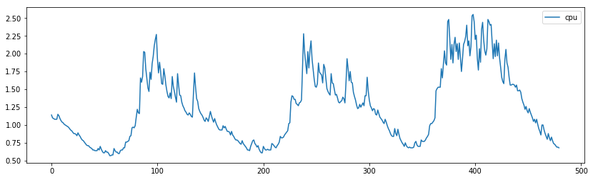

```python
import os
import pandas as pd
import matplotlib.pyplot as plt
%matplotlib inline
plt.rcParams['figure.figsize'] = (14, 4)
dataset = pd.read_csv(os.path.join(os.getcwd(), 'datasets', 'cpu-a.csv'))
_ = dataset.plot()
```

```python
import numpy as np
n_grams = []
for i in range(len(dataset)):
    n_grams.append(dataset.cpu[i:i+5].values.tolist())
n_grams = np.array([g for g in n_grams if len(g) == 5])
print("Four last 5-grams:")
n_grams[-4:]
```

```
Four last 5-grams:
```

```
array([[0.83, 0.78, 0.74, 0.73, 0.71],
       [0.78, 0.74, 0.73, 0.71, 0.69],
       [0.74, 0.73, 0.71, 0.69, 0.69],
       [0.73, 0.71, 0.69, 0.69, 0.68]])
```

```python
n_grams_norm = n_grams/n_grams.max()
n_grams_norm
```

```
array([[0.44705882, 0.43137255, 0.42745098, 0.42352941, 0.42352941],
       [0.43137255, 0.42745098, 0.42352941, 0.42352941, 0.42352941],
       [0.42745098, 0.42352941, 0.42352941, 0.42352941, 0.45098039],
       ...,
       [0.30588235, 0.29019608, 0.28627451, 0.27843137, 0.27058824],
       [0.29019608, 0.28627451, 0.27843137, 0.27058824, 0.27058824],
       [0.28627451, 0.27843137, 0.27058824, 0.27058824, 0.26666667]])
```

Yhden 5-grammin ensimmäiset neljä arvoa muodostavat aina syötesekvenssin ja viimeinen viides on ennustuksen kohdearvo. Tätä tietoa hyödyntämällä muodostetaan `Dataset`-luokkaan pohjaava `CPUDataset`, joka tuottaa syöte-kohde-pareja riveittäin LSTM-verkon vaatimassa muodossa. Syöte- ja kohdedatarivit sisältävä `CPUDataset` kääritään vielä edelleen `fastai.data.DataBunch`-luokkaan, jotta koulutusta virtaviivaistavan `fastai`-kirjaston käyttö mahdollistuu (vrt. Keras ja Tensorflow).

```python
import torch
import torch.utils.data as data
import torch.nn.utils.rnn as rnn_utils


class CPUDataset(data.Dataset):
    def __init__(self, n_grams):
        self.data = torch.Tensor(n_grams)

    def __getitem__(self, index):
        return (self.data[index, :-1].contiguous().view(4, -1),  # Required shape [seq_l, data]
                self.data[index, -1])

    def __len__(self):
        return len(self.data)
```

```python
train = CPUDataset(n_grams_norm[:-66])
validate = CPUDataset(n_grams_norm[-66:])
print("Koulutusdatajoukon koko:", len(train))
print("Validointidatajoukon koko:", len(validate))
```

```
Koulutusdatajoukon koko: 410
Validointidatajoukon koko: 66
```

```python
from fastai.data import DataBunch
data_bunch = DataBunch.create(
    train_ds=train, valid_ds=validate, num_workers=0, bs=2)
```

Seuraavaksi määritellään LSTM-malli.

```python
import torch.nn as nn
model = nn.LSTM(input_size=1, hidden_size=4, batch_first=True)
model.cuda()
```

```
LSTM(1, 4, batch_first=True)
```

Tämän jälkeen on vuorossa mallin koulutus.

```python
from fastai.train import Learner, ShowGraph
from torch.optim import RMSprop


def rnn_mse(pred, target): return nn.MSELoss()(pred[0][:, -1, -1], target)


learner = Learner(data=data_bunch, model=model, opt_fn=RMSprop,
                  loss_fn=rnn_mse, callback_fns=ShowGraph)
```

```
Total time: 00:05
epoch  train loss  valid loss
0      0.018622    0.012186    (00:00)
1      0.005813    0.003616    (00:00)
2      0.004859    0.005745    (00:00)
3      0.005382    0.003728    (00:00)
4      0.004762    0.004360    (00:00)
5      0.005388    0.003496    (00:00)
6      0.003505    0.003420    (00:00)
7      0.004433    0.002590    (00:00)
8      0.003617    0.003050    (00:00)
9      0.004090    0.002701    (00:00)
```

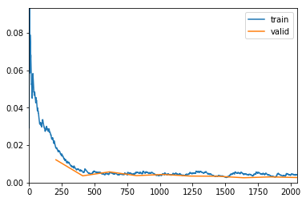

```python
learner.fit(epochs=10)
```

Koulutuksen jälkeen on vuorossa sovittumisen tarkastelu. Aloitetaan koulutusdatalla.

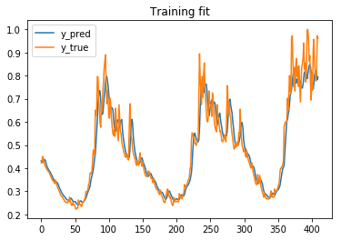

```python
y_train_pred = []
y_train_true = []
for x, y in data.DataLoader(train):
    y_train_pred.append(
        model(x.cuda())[0][:, -1, -1].detach().cpu().numpy()[0])
    y_train_true.append(y.numpy()[0])
_ = pd.DataFrame([y_train_pred, y_train_true], index=[
                 'y_pred', 'y_true']).T.plot(title="Training fit")
```

Malli sovittuu melko hyvin. Koitetaan seuraavaksi mallin ennustekykyä sille tuntemattomilla havainnoilla.

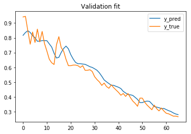

```python
y_validate_pred = []
y_validate_true = []
for x, y in data.DataLoader(validate):
    y_validate_pred.append(
        model(x.cuda())[0][:, -1, -1].detach().cpu().numpy()[0])
    y_validate_true.append(y.numpy()[0])
_ = pd.DataFrame([y_validate_pred, y_validate_true], index=[
                 'y_pred', 'y_true']).T.plot(title="Validation fit")
```

#### Statistical Metrics

Algoritmien lisäksi poikkeamia voidaan havaita myös tilastollisella analyysillä (*statistical analysis*). Esimerkiksi datasta ylläpidettävän liukuvan ikkunan keskiarvon käyttö vertailukohteena uusille havainnoille on tällaista tilastollista analyysiä, missä liian suuri poikkeama keskiarvosta tulkitaan ainakin tutkimisen arvoiseksi tapahtumaksi. Seuravaaksi esitellään kaksi merkittävää tilastollista testiä.

Tilastollinen poikkeama-analyysi on yksinkertaista ja tehokasta. Samoin sen luokittelutulosten tulkinnallisuus säilyy hyvänä, jolloin perustavampiin syy-yhteyksiin on helpompi päästä käsiksi. Menetelmät eivät välttämättä tarjoa parasta tarkkuutta, mutta joissain tapauksissa niiden yksinkertaisuus ja implementoinnin helppous painavat vaa'assa äärimmäistä tarkkuutta enemmän.

##### Median absolute deviation

Mediaani absoluuttinen poikkeama lasketaan yksinkertaisuudessaan seuraavasti.

```python
import numpy as np

x = [-5,1,2,3,4,5,6,7] #Yksi poikkeava arvo: -5
mad_full = np.median(np.abs(x-np.median(x)))
mad_clean = np.median(np.abs(x[1:]-np.median(x[1:])))
print("Poikkeavan arvon sisältävän joukon mediaani ja MAD:",mad_full)
print("Siistityn joukon mediaani ja MAD:",mad_clean)
```

[output not shown]

Vertailun vuoksi lasketaan vielä samoilla joukoilla keskihajonnat.

```python
print("Poikkeavan arvon sisältävän joukon keskiarvo ja -hajonta:",np.mean(x),"+-",np.std(x))
print("Siistityn joukon keskiarvo ja -hajonta:",np.mean(x[1:]),"+-",np.std(x[1:]))
```

```
Poikkeavan arvon sisältävän joukon keskiarvo ja -hajonta: 2.875 +- 3.515590277606308
Siistityn joukon keskiarvo ja -hajonta: 4.0 +- 2.0
```

Ero on merkittävä.

##### Grubb's outlier test

Grubbsin testiä käytetään yksittäisen poikkeaman löytämiseen normaalijakautuneesta datasta joko maksimi- tai minimiarvosta. Testi on iteratiivinen algoritmi, jolla käydään koko datasetti läpi ja merkitään mahdolliset poikkeamat. Menetelmä kärsii kuitenkin normaalijakaumavaatimuksesta ja siitä, että kullakin iteraatiolla löydetään vain yksi poikkeama kerrallaan.

#### Goodness-of-Fit

Poikkeamia havaitsevan mallin rakentamisessa on tärkeä olla selvillä siitä missä määrin rakentamiseen käytettävässä datassa on itsessään poikkeavia havaintoja. Tämä edellyttää riittävää tietoa niin sanotusta datan domainista, eli datan tuotattaneista tapahtumista ja ympäristöstä, jota dataa pyrkii kuvaamaan. Käytännössä mikään datajoukko ei ole täydellisesti johonkin tilastolliseen jakaumaan sopiva, josta seuraa tarve penkoa dataa huolellisemmin.

Sovittuvuuden testit (*goodness-of-fit*), joihin lukeutuvat mm. neliöllinen chi-testi (*chi-squared*) ja Kolmogorov-Smirnovin testi, soveltuvat muuttujien tilastollisen samankaltaisuuden tarkasteluun. Nämä testit toimivat parhaiten yhden piirteen datajoukoilla, minkä vuoksi käytännön ongelmiin kannattaa käyttää paremmin soveltuvia menetelmiä. Näitä esitellään seuraavaksi.

##### Elliptic envelope fitting (covariance estimate fitting)

Ellipsikäyrän sovitus toimii hyvin normaalijakautuneen datajoukon poikkeamien tunnistamisessa. Lähtökohdissaan menetelmä vaatii tietoa tai ainakin riittävän pätevän arvion ei-poikkeavien havaintojen jakaumasta. Joskaan, kuten jo mainittua, tällaista jakaumaan ei todellisuudessa ole olemassa, tämän arvion pohjalta on mahdollista muodostaa esimerkiksi kahden muuttujan avulla raja, jonka sisäpuolella olevat pisteet ovat normaaleja havaintoja ja ulkopuoliset poikkeamia.

Esitellään tätä esimerkin avulla. Määritellään ensin data ja siihen poikkeamia, minkä jälkeen visualisoidaan kokonaisuus.

```python
import numpy as np
n_inliers = 990
n_outliers = 10
data_inliers = np.random.randn(n_inliers,2) # x- ja y-akselit
data_outliers = np.random.uniform(low=-10,high=10,size=(n_outliers,2)) #x- ja y-akselit
```

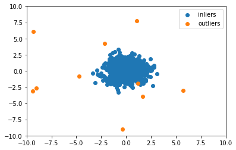

```python
import matplotlib.pyplot as plt
plt.scatter(data_inliers[:,0],data_inliers[:,1],label='inliers')
plt.scatter(data_outliers[:,0],data_outliers[:,1],label='outliers')
plt.xlim(-10,10);plt.ylim(-10,10);plt.legend();plt.show()
```

Datajoukon generoinnin jälkeen käytetään `sklearn.covariance.EllipticEnvelope`-luokkaa ellipsikäyrän sovittamiseen. Menetelmä löytyy kovarianssimenetelmien moduulista ja kovarianssilla tarkoitetaan muuttujien keskinäisen vuorovaikutuksen tuloksena syntyvän datan vaihtelun arvoa - kuinka paljon muuttuja muuttuu toisen muuttuessa siis.

```python
from sklearn.covariance import EllipticEnvelope
x = np.concatenate([data_inliers,data_outliers])
classifier = EllipticEnvelope(contamination=(n_outliers/n_inliers))
classifier.fit(x)
predicted_labels = classifier.predict(x)
pred_inliers = x[predicted_labels==1]
pred_outliers = x[predicted_labels==-1]
```

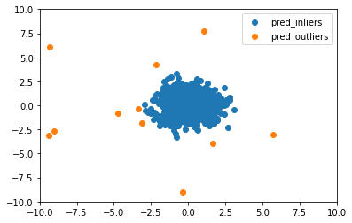

```python
import matplotlib.pyplot as plt
plt.scatter(pred_inliers[:,0],pred_inliers[:,1],label='pred_inliers')
plt.scatter(pred_outliers[:,0],pred_outliers[:,1],label='pred_outliers')
plt.xlim(-10,10);plt.ylim(-10,10);plt.legend();plt.show()
```

```python
print(f"Todellinen poikkeama-oikea-suhde: {n_outliers/n_inliers:.4f}")
print(f"Ennusteen poikkeama-oikea-suhde:  {pred_outliers.shape[0]/pred_inliers.shape[0]:.4f}")
```

```
Todellinen poikkeama-oikea-suhde: 0.0101
Ennusteen poikkeama-oikea-suhde:  0.0111
```

Eroa on vain yhden pisteen kohdalla, joten luokittelutulos on erittäin hyvä tuhannen havainnon kohdalla. Tämä toisaalta on mahdollista selittää datajoukon selkeän jakautuneisuuden kautta (normaalijakauma vs. tasajakauma). Menetelmän toiminnan ytimessä on myös tieto siitä, missä määrin datassa esiintyy poikkeavia havaintoja (luokan alustuksen `contamination` parametri). Synteettisessä esimerkissä tämä tieto on suoraan saatavilla, mutta todellisen elämän ongelmassa tieto on usein vain valistunut arvaus tai oletus. Joka tapauksessa arvoa on säädeltävä halutun tarkkuuden tavoittamiseksi.Menetelmä ei kuitenkaan toimi kovin hyvin muille kuin normaalijakautuneille datajoukoille. Ne toimivat paremmin myös ennemmin matala- kuin korkeapiirteisen datan kanssa.

#### Unsupervised Machine Learning Algorithms

Ohjatun oppimisen lisäksi myös ohjaamattomia menetelmiä voidaan käyttää poikkeamien havaitsemiseen. Joissain menetelmissä onkin kyseessä ohjatun menetelmän muokkaus ohjaamattomaksi tavoitteen saavuttamiseksi. Seuraavaksi tarkastellaan muutamaa tällaista menetelmää.

##### One-class support vector machines

Vain yhteen luokkaan sovitettuja tukivektorikoneita voidaan käyttää poikkeamien havaitsemiseen, kunhan koulutukseen käytetyssä datajoukossa ei ole itsessään poikkeaviksi luokiteltavia havaintoja. Näin koulutettuna malli voidaan käyttää tunnistamaan koulutusdatasta poikkeavat havainnot. Menetelmä soveltuu mainiosti multimodaalisen (monta keskittymää tai merkittävää aluetta) ja korkeapiirteisen datan luokitteluun.

Edetään jälleen esimerkin kautta, jossa datana käytetään edellisen kohdan synteettistä esimerkkidataa, joskin siten muutettuna, että oikeita havaintoja löytyy kahdessa ryppäässä.

```python
import numpy as np
n_inliers = 990
n_outliers = 10
data_inliers_1 = np.random.randn(int(n_inliers/2),2)-3 # x- ja y-akselit
data_inliers_2 = np.random.randn(int(n_inliers/2),2)+3 # x- ja y-akselit
data_inliers = np.concatenate([data_inliers_1,data_inliers_2])
data_outliers = np.random.uniform(low=-10,high=10,size=(n_outliers,2)) #x- ja y-akselit
x = np.concatenate([data_inliers,data_outliers])
```

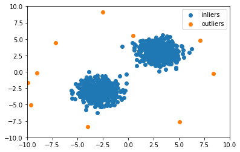

```python
import matplotlib.pyplot as plt
plt.scatter(data_inliers[:,0],data_inliers[:,1],label='inliers')
plt.scatter(data_outliers[:,0],data_outliers[:,1],label='outliers')
plt.xlim(-10,10);plt.ylim(-10,10);plt.legend();plt.show()
```

Käytettävä malli on `sklearn.svm`-moduulin `OneClassSVM`. Tärkein määriteltävä parametri on `nu`, jolla algoritmille kerrotaan datassa olevien poikkeamien suurpiirteiden suhde. Toinen merkittävä parametri on `gamma`, jolla säädellään menetelmän käyttämää radiaalikernelin kokoa. Aiheesta on mainittu jo viime luvussa SVM-menetelmän yhteydessä.

```python
from sklearn import svm
classifier = svm.OneClassSVM(gamma=0.01,nu=n_outliers/n_inliers)
classifier.fit(x)
predicted_labels = classifier.predict(x)
pred_inliers = x[predicted_labels>0]
pred_outliers = x[predicted_labels<0]
```

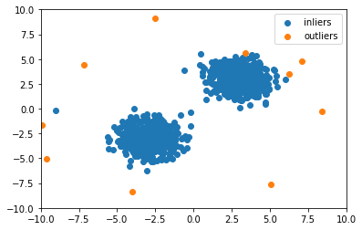

```python
import matplotlib.pyplot as plt
plt.scatter(pred_inliers[:,0],pred_inliers[:,1],label='inliers')
plt.scatter(pred_outliers[:,0],pred_outliers[:,1],label='outliers')
plt.xlim(-10,10);plt.ylim(-10,10);plt.legend();plt.show()
```

```python
print(f"Todellinen poikkeama-oikea-suhde: {n_outliers/n_inliers:.4f}")
print(f"Ennusteen poikkeama-oikea-suhde:  {pred_outliers.shape[0]/pred_inliers.shape[0]:.4f}")
```

```
Todellinen poikkeama-oikea-suhde: 0.0101
Ennusteen poikkeama-oikea-suhde:  0.0101
```

Menetelmä kykeni onnistuneesti luokittelemaan kaksi isompaa rypästä oikein ja se tunnisti myös suhteellisen hyvin ryppäiden ulkopuoliset havainnot poikkeamiksi. Menetelmän tuotantokäyttö edellyttää kuitenkin erityistä huolellisuutta siinä, ettei mallin jatkuvan koulutuksen yhteydessä datajoukkoon lipsahda poikkeamia väärin luokiteltuna - menetelmä on hyvin herkkä poikkeamia sisältävälle datalle.

##### Isolation Forests

Satunnaismetsäluokittelijat (*random forest classifiers*) tunnetusti toimivat hyvin jopa korkeapiirteisten datajoukkojen kanssa. Satunnaismetsät ovat siis monesta puuluokittimesta muodostettu ensemble-malli, mistä juontaa niiden laskennallinen tehokkuus esimerkiksi jatkuvan datavirran (*stream*) käsittelyssä. Tähän malliin pohjaavat erottelumetsät (*isolation forests*) tutkivat datan havainnot pyrkien erottelemeaan kunkin havainnon lopuksi puu-mallin omaksi lehdekseen. Perustavana ajatuksena on, että poikkeavat havainnot päätyvät puumallin lehdiksi tavanomaisia havaintoja nopeammin, sillä tavanomaisten havaintojen erottely vaatii paljon hienosyisempää erottelua lisäten puun syvyyttä niiden osalta. Intuitiivisesti ajateltuna poikkeamat löytyvät puun matalimmilta oksilta.

Esimerkkiä varten otetaan käyttöön `sklearn.ensemble`-moduulin `IsolationForest`-luokka. Datana käytetään edellistä datasettiä sellaisenaan.

```python
from sklearn.ensemble import IsolationForest
classifier = IsolationForest(max_samples=n_inliers+n_outliers, contamination=n_outliers/n_inliers,behaviour='new')
classifier.fit(x)
predicted_labels = classifier.predict(x)
pred_inliers = x[predicted_labels==1]
pred_outliers = x[predicted_labels==-1]
```

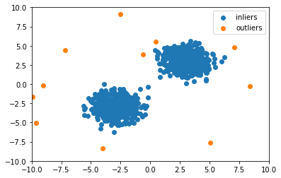

```python
import matplotlib.pyplot as plt
plt.scatter(pred_inliers[:,0],pred_inliers[:,1],label='inliers')
plt.scatter(pred_outliers[:,0],pred_outliers[:,1],label='outliers')
plt.xlim(-10,10);plt.ylim(-10,10);plt.legend();plt.show()
```

```python
print(f"Todellinen poikkeama-oikea-suhde: {n_outliers/n_inliers:.4f}")
print(f"Ennusteen poikkeama-oikea-suhde:  {pred_outliers.shape[0]/pred_inliers.shape[0]:.4f}")
```

```
Todellinen poikkeama-oikea-suhde: 0.0101
Ennusteen poikkeama-oikea-suhde:  0.0111
```

Menetelmä suoriutui yksiluokkaista tukivektorikonetta paremmin visuaalisen tarkastelun perusteella ja vaati myös vähemmän manuaalista parametrien säätöä.

#### Density-Based Methods

Ryhmittelymenetelmiä voidaan käyttää myös poikkeamien luokittelussa ja ne soveltuvat mm. korkeapiirteisen datan käsittelyyn. Jokaisen poikkeamien havaitsemiseen kehitetyn ryhmittelymenetelmän perustana on ryhmitellä datan yksittäiset havainnot tiiviiksi ryppäiksi. Tällöin kimppujen väliin jäävät havainnot käsitellään poikkeamina. Nämä menetelmät ovat hyvin vastustuskykyisiä datajoukossa piileviä poikkeamia vastaan, sillä poikkeavat havainnot jäävät lähestulkoon joka tapauksessa ryppäiden välimaastoon.

Esimerkiksi perinteisiä ryhmittelymenetelmiä, kuten $k$-lähimmän naapurin menetelmää ja $k$-keskiarvoryhmittelyä, voidaan käyttää helpohkosti sellaisenaan. Tässä kohdin keskitytään kuiteknin paikallisen poikkeamafaktorin (*local outlier factor, LOF*) menetelmään.

##### Local outlier factor

Paikallisen poikkeamafaktorin menetelmä on preinteinen poikkeamien havaitsemiseen käytetty havaintojen ryhmittelyyn perustuva algoritmi. Läheisyyden sijasta menetelmä keskittyy kunkin havainnon eristyineisyyden mittaamiseen suhteessa muihin havaintoihin. Mikäli jollain havainnolla on huomattavasti suurempi eristyneisyys suhteessa sen lähimpiin havaintoihin, luokittellaan havainto poikkeamaksi.

Menetelmä löytyy `sklearn.neighbors`-moduulista luokkana `LocalOutlierFactor`. Datana käytetään edelleen samaa kaksiryppäistä dataa.

```python
from sklearn.neighbors import LocalOutlierFactor
classifier = LocalOutlierFactor(n_neighbors=300,contamination='auto')
predicted_labels = classifier.fit_predict(x)
pred_inliers = x[predicted_labels==1]
pred_outliers = x[predicted_labels==-1]
```

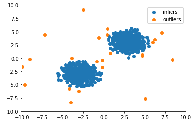

```python
import matplotlib.pyplot as plt
plt.scatter(pred_inliers[:,0],pred_inliers[:,1],label='inliers')
plt.scatter(pred_outliers[:,0],pred_outliers[:,1],label='outliers')
plt.xlim(-10,10);plt.ylim(-10,10);plt.legend();plt.show()
```

```python
print(f"Todellinen poikkeama-oikea-suhde: {n_outliers/n_inliers:.4f}")
print(f"Ennusteen poikkeama-oikea-suhde:  {pred_outliers.shape[0]/pred_inliers.shape[0]:.4f}")
```

```
Todellinen poikkeama-oikea-suhde: 0.0101
Ennusteen poikkeama-oikea-suhde:  0.0235
```

Ryhmittelymenetelmille ominaisesti myös LOF suorittaa jokaisen havainnon kohdalla vertailulaskelmat suhteessa toisiin havaintoihin. Suurten datajoukkojen kanssa tämän menetelmän käyttö voi siis käydä melko raskaaksi. Menetelmä osaa eritellä multimodaalista dataa hyvin, eikä tarkkuuskaan ole hirvittävän huono. Sitä ei myöskään juuri tarvitse säätää, kunhan lähimpien naapurien määrä asetetaan dataan sopivaksi.

### Challenges of Using Machine Learning in Anomaly Detection